[figure not shown]

# Predicting the Success of a Reddit Post

Anchit Jain

## Introduction

Ever head about Reddit? Chances are that you have most probably seen Reddit in News for [solving murder mystery](https://www.vocativ.com/408523/subreddit-solved-20-year-old-mystery/index.html) or you have already visited it to download a book(if you are a student who believes in saving money from buying textbooks) or simply to read [news](https://www.reddit.com/r/news/). Nonetheless, Reddit is the [6th most visited website in the U.S.](https://www.alexa.com/topsites/countries/US) Reddit is a "social news aggregation forum", which is to say that Reddit simply collects information from all over the internet and displays it in one place. Reddit is divided into Subreddits which are focused on a particular type of content. So, if you are a fan of the show "Survivor" then you could find a SubReddit on [Survivor](https://www.reddit.com/r/survivor/) or if you really love the NBA then you could hunt around on [NBA](https://www.reddit.com/r/nba/). These SubReddits are moderated by users and their posts are also made bcy users. Good posts on reddit or any sort of viral posts on Reddit have a high "upvote" number which is displayed next to each post on reddit and the most upvoted posts are shown on the site's [front page](https://www.reddit.com/r/all). If you want to find more about Reddit then you can visit this Subreddit[Reddit 101](https://www.reddit.com/r/Reddit101/) or you can visit [here](https://lifehacker.com/a-beginners-guide-to-reddit-1798643829).

With over 330 million users and over 20 thousand daily submissions, it’s hard to predict which posts will get popular enough to hit the front page. If your predictions were good enough to craft viral Reddit posts, though, you could get your ideas out to those millions of users in a matter of hours. Many users don’t realize that Reddit can be- and is already being- manipulated to spread more than cute cats. [Large financial service companies use Reddit](https://www.forbes.com/sites/jaymcgregor/2017/02/20/reddit-is-being-manipulated-by-big-financial-services-companies/#109284f94c92) to boost their online image, and just this month the Reddit team claimed [leaked U.S.-U.K. trade documents posted on their site](https://time.com/5745917/reddit-uk-trade-documents-russia/) were part of a large-scale misinformation campaign originating from Russia. On top of getting your own upvotes, understanding what makes a Reddit post popular is critical for your informed online browsing.

Given the huge amount of data Reddit generates, it’s also an interesting problem for data science: based on existing Reddit posts, can we identify the most important features of a successful post and predict a post’s success before it’s submitted? In this tutorial, my goal is to download and tidy data from Reddit, perform some exploratory analysis to identify important features, then use machine learning models to predict a post’s upvote rating based on those features. For readers unfamiliar with Reddit, I hope that my analysis will get you interested in the site and in some popular posts. For more experienced readers, I hope to give you some insight into how your favorite “social news aggregation forum” works, and show you how to get your own posts to the front page of the internet.

## Installation and loading of Libraries

All of the third-party libraries can be installed by executing the following commands:

$ sudo pip install pytorch

$ sudo pip install pandas

$ sudo pip install matplotlib

$ sudo pip install seaborn

$ sudo pip install -U scikit-learn

$ sudo pip install numpy

$ sudo pip install praw

After you are done with installing these third parties in your environment, you will have to load them in to use their functions, so you can go ahead and run the following lines of code

```python
from textblob import TextBlob
import torch
import torch.nn as nn
import torch.optim as optim
import pandas as pd
import matplotlib.pyplot as plt
import seaborn as sns
from sklearn.linear_model import Lasso, LogisticRegression
from sklearn.ensemble import RandomForestRegressor
import sklearn.metrics as metrics
from sklearn.model_selection import train_test_split
import numpy as np
import praw
import seaborn as sns
import statsmodels.api as sm
from statsmodels.stats.outliers_influence import variance_inflation_factor
import warnings
warnings.filterwarnings("ignore")
```

### Data Collection via Web Scraping

To scrape data from Reddit, I will make use of [PRAW (the Python Reddit API Wrapper)](https://praw.readthedocs.io/en/latest/). For this analysis, I chose to pull data into three datasets:

This gives us a good spread of recent posts that have been both popular and not so popular. For users with a better understanding of web scraping, I scraped Reddit's posts using the Reddit API and a developer's application that I created for this project. For more information regarding Reddit Apps and how they are used for scraping, please check out this Medium post [here](https://towardsdatascience.com/scraping-reddit-data-1c0af3040768).

```python
# Here I use my personal clientID and clientSecret number to connect to my App.
# If you are interested in performing this analysis with your app then please check out the above link and
# feel free to conduct this analysis with your own Application.

# Connect to my Reddit Developer's App using Reddit's API
clientID = 'zPbzMNhBosNflA' #My clientID
clientSecret = 'Qzw318O35ccKiZ7ZlOa-zkbA17g' #My Secret ID number
userAgent = 'RedditScrape' #The name of my Developer App
reddit = praw.Reddit(client_id=clientID, client_secret=clientSecret, user_agent=userAgent) #Connection using PRAW
```

```python
# This code is used to scrape the different types of data and store them in different csv files
# This first portion scrapes the top posts only
top_posts = []
sub = reddit.subreddit('all')
for post in sub.top(time_filter = 'year', limit=1000):
    top_posts.append([post.title, post.score, post.id, post.subreddit, post.url, post.num_comments, post.selftext, post.created_utc, post.author, post.is_self, post.over_18, post.spoiler, post.upvote_ratio, post.ups, post.subreddit_subscribers])
top_posts = pd.DataFrame(top_posts, columns=['title', 'score', 'id', 'subreddit', 'url', 'num_comments', 'body', 'created', 'author', 'is_self', 'over_18', 'spoiler', 'upvote_ratio', 'upvotes', 'subreddit_subscribers'])
top_posts.to_csv("top1000posts.csv", index=False)

# This portion scrapes the controversial posts
controversial_posts = []
for post in sub.controversial(time_filter = 'year', limit=1000):
    controversial_posts.append([post.title, post.score, post.id, post.subreddit, post.url, post.num_comments, post.selftext, post.created_utc, post.author, post.is_self, post.over_18, post.spoiler, post.upvote_ratio, post.ups, post.subreddit_subscribers])
controversial_posts = pd.DataFrame(controversial_posts, columns=['title', 'score', 'id', 'subreddit', 'url', 'num_comments', 'body', 'created', 'author', 'is_self', 'over_18', 'spoiler', 'upvote_ratio', 'upvotes', 'subreddit_subscribers'])
controversial_posts.to_csv("contro1000posts.csv", index=False)

# This portion scrapes random posts
posts = []
#limit = 0
sub = reddit.subreddit('all')
for limit in range(500):
    post = sub.random()
    #print(limit) #This is a good way of checking how fast or slow the scraping is going
    posts.append([post.title, post.score, post.id, post.subreddit, post.url, post.num_comments, post.selftext, post.created_utc, post.author, post.is_self, post.over_18, post.spoiler, post.upvote_ratio, post.ups, post.subreddit_subscribers])
    limit = limit+1
posts = pd.DataFrame(top_posts, columns=['title', 'score', 'id', 'subreddit', 'url', 'num_comments', 'body', 'created', 'author', 'is_self', 'over_18', 'spoiler', 'upvote_ratio', 'upvotes', 'subreddit_subscribers'])
posts.to_csv("rando1000posts.csv", index=False)
```

[output not shown]

[output cut: 445 more lines]

[output not shown]

Since the scraping take a few minutes, I have decided to store the scrapes in CSV files and avoid calling the API again and again. After saving those CSVs, we will load them into our current environment as Pandas Dataframe enables us to have large functionality in terms of access and modification. If you are unfamiliar with a DataFrame and the pandas library then please feel free to check out [this link if you are completely new to DataFrames](https://www.datacamp.com/community/tutorials/pandas-tutorial-dataframe-python)

or [if you have some experience and would like a deeper understanding](https://www.geeksforgeeks.org/python-pandas-dataframe/). For more info on Pandas, check out their docs at [.](https://pandas.pydata.org/docs/)

```python
# We use pandas read_csv function to load these csv files as DataFrame in our current environment.
topPosts = pd.read_csv("top1000posts.csv")
controversialPosts = pd.read_csv("contro1000posts.csv")
randomPosts = pd.read_csv("rando1000posts.csv")
```

```python
topPosts.head()
```

|  | title | score | id | subreddit | url | num_comments | body | created | author | is_self | over_18 | spoiler | upvote_ratio | upvotes | subreddit_subscribers |
| --- | --- | --- | --- | --- | --- | --- | --- | --- | --- | --- | --- | --- | --- | --- | --- |
| 0 | You fell for it fool! | 285666 | cjlngm | YouFellForItFool | https://i.redd.it/1wbz4b15vcd31.jpg | 16122 | NaN | 1.564455e+09 | spectra2000_ | False | False | False | 1.00 | 285666 | 88488 |
| 1 | Take your time, you got this | 268695 | ccr8c8 | gaming | https://i.redd.it/5ugttvttk3a31.jpg | 3636 | NaN | 1.563035e+09 | SrGrafo | False | False | False | 0.98 | 268695 | 26270096 |
| 2 | If this is you: Fuck you | 247421 | fi2zjs | pics | https://i.redd.it/b9hkx5md2hm41.jpg | 15875 | NaN | 1.584119e+09 | onyxandcake | False | False | False | 0.94 | 247421 | 24643127 |
| 3 | Ever since my niece saw Toy Story, she shouts ... | 232005 | ehb706 | aww | https://i.redd.it/nbf6kvcbwm741.jpg | 2061 | NaN | 1.577652e+09 | finestjun | False | False | False | 0.96 | 232005 | 24815599 |
| 4 | Blizzard Employees Staged a Walkout After the ... | 226320 | dfn3yi | news | https://www.thedailybeast.com/blizzard-employe... | 9652 | NaN | 1.570654e+09 | SageMo | False | False | False | 0.97 | 226320 | 20642854 |

```python
controversialPosts.head()
```

|  | title | score | id | subreddit | url | num_comments | body | created | author | is_self | over_18 | spoiler | upvote_ratio | upvotes | subreddit_subscribers |
| --- | --- | --- | --- | --- | --- | --- | --- | --- | --- | --- | --- | --- | --- | --- | --- |
| 0 | Liberals would rather act like this is what th... | 0 | facyn7 | Conservative | https://i.redd.it/nq3wpcyl9hj41.jpg | 908 | NaN | 1.582814e+09 | SpencerScott444 | False | False | False | 0.50 | 0 | 336019 |
| 1 | Elon Musk's promised ventilators never deliver... | 0 | g2edod | news | https://www.foxcarolina.com/elon-musks-promise... | 401 | NaN | 1.587042e+09 | Billy_Lo | False | False | False | 0.50 | 0 | 20642857 |
| 2 | <3 | 0 | g1moel | PoliticalCompass | https://i.redd.it/a7f4b99sgxs41.jpg | 577 | NaN | 1.586933e+09 | spidermanisback78 | False | False | False | 0.49 | 0 | 21058 |
| 3 | Hi. I'm Beto O'Rourke, a candidate for President. | 10272 | d6etv5 | IAmA | https://www.reddit.com/r/IAmA/comments/d6etv5/... | 26878 | Hi everyone -- Beto O’Rourke here. I’m a candi... | 1.568903e+09 | betoorourke | True | False | False | 0.55 | 10272 | 20069088 |
| 4 | I wish for 420 upvotes on this post but 1000 d... | 506 | ey0ax8 | TheMonkeysPaw | https://www.reddit.com/r/TheMonkeysPaw/comment... | 163 | EDIT: so we managed to achieve our dream but t... | 1.580699e+09 | superdog0608 | True | False | False | 0.51 | 506 | 432362 |

```python
randomPosts.head()
```

|  | title | score | id | subreddit | url | num_comments | body | created | author | is_self | over_18 | spoiler | upvote_ratio | upvotes | subreddit_subscribers |
| --- | --- | --- | --- | --- | --- | --- | --- | --- | --- | --- | --- | --- | --- | --- | --- |
| 0 | You fell for it fool! | 285666 | cjlngm | YouFellForItFool | https://i.redd.it/1wbz4b15vcd31.jpg | 16122 | NaN | 1.564455e+09 | spectra2000_ | False | False | False | 1.00 | 285666 | 88488 |
| 1 | Take your time, you got this | 268695 | ccr8c8 | gaming | https://i.redd.it/5ugttvttk3a31.jpg | 3636 | NaN | 1.563035e+09 | SrGrafo | False | False | False | 0.98 | 268695 | 26270096 |
| 2 | If this is you: Fuck you | 247421 | fi2zjs | pics | https://i.redd.it/b9hkx5md2hm41.jpg | 15875 | NaN | 1.584119e+09 | onyxandcake | False | False | False | 0.94 | 247421 | 24643127 |
| 3 | Ever since my niece saw Toy Story, she shouts ... | 232005 | ehb706 | aww | https://i.redd.it/nbf6kvcbwm741.jpg | 2061 | NaN | 1.577652e+09 | finestjun | False | False | False | 0.96 | 232005 | 24815599 |
| 4 | Blizzard Employees Staged a Walkout After the ... | 226320 | dfn3yi | news | https://www.thedailybeast.com/blizzard-employe... | 9652 | NaN | 1.570654e+09 | SageMo | False | False | False | 0.97 | 226320 | 20642854 |

Now we will look at 10 Subreddits in Top1000 posts, Top 1000 controversial posts and the 500 random posts.

```python
#Top 10 List of subreddits that have broken top 1k
topSubReddit = topPosts.subreddit.unique()
topSubReddit[0:10]
```

```
array(['YouFellForItFool', 'gaming', 'pics', 'aww', 'news', 'funny',
       'memes', 'space', 'worldnews', 'gifs'], dtype=object)
```

```python
#Top 10 subreddits that have broken most controversial 1k
controversialSubReddits = controversialPosts.subreddit.unique()
controversialSubReddits[0:10]
```

```
array(['Conservative', 'news', 'PoliticalCompass', 'IAmA',
       'TheMonkeysPaw', 'politics', 'WhereAreAllTheGoodMen', 'videos',
       'FortNiteBR', 'pathofexile'], dtype=object)
```

```python
#Top 10 subreddits that have broken most random 500
randomSubReddits = randomPosts.subreddit.unique()
randomSubReddits[0:10]
```

```
array(['YouFellForItFool', 'gaming', 'pics', 'aww', 'news', 'funny',
       'memes', 'space', 'worldnews', 'gifs'], dtype=object)
```

The controversial sample of subreddits shows a few different trends. Of the 269 subreddits that have broken the controversial 1000, many (like [r/Conservative](https://www.reddit.com/r/Conservative/) and [r/news](https://www.reddit.com/r/News/)), have been popular because of the current polarized political climate which has been excerbated by the outbreak of the coronavirus. However, subreddits like [r/IAmA](https://www.reddit.com/r/IAmA/) are communities where people anonymously discuss their innermost feelings and thoughts which are bound to be popular. Surprisingly, though, there was a controversial subreddit that has now become a part of **popular entertainment** which was [r/FortNiteBR](https://www.reddit.com/r/FortNiteBR/). I believe that there was some sampling bias because due to the coronavirus outbreak, everyone has been watching the news excessivley which has meant that a majority of the controversial subreddits are related to politics. This means that my data could potentially have a lot of political posts which would skew the data because normal traffic of Reddit is made up of other popular subreddits like "ShowerThoughts" and "TrueOffMyChest" which house a lot of sentimental and emotional posts which are popular.

From this data, it seems that posting to large generic subreddits and avoiding specific potentially-controversial subreddit may help your post get a lot of upvotes. Therefore, I hypothesize that **a post's subreddit is an important feature in its success**.

### Data Preprocessing and cleaning

Now, I'll have to clean up the data from PRAW to get it into a more usable format. I'll be combining the top, controversial and random posts into a single Pandas dataframe, adding a field to differentiate between them, and dropping some features that are not controlled by the user and irrelavant to our analysis (like url and reddit's internal post id). I will also remove duplicate posts and limit our table to only the 1000 most popular posts. I believe that hypothesizing and testing which features affect the upvotes will be much more potent in these 1000 posts rather than the whole dataset.

```python
# We will one hot encoding the the controversial, top and random posts by 0,1 and 2.
controversialPosts['post_category'] = 0
topPosts['post_category'] = 1
randomPosts['post_category'] = 2

# We will combine all of these dataframes into one giant dataframe
data = pd.concat([topPosts, controversialPosts, randomPosts])
data = data.reset_index() #Resets the indices
data = data.drop(["id", "index", "url", "body"], axis=1) #Dropping irrelevant features
data
```

|  | title | score | subreddit | num_comments | created | author | is_self | over_18 | spoiler | upvote_ratio | upvotes | subreddit_subscribers | post_category |
| --- | --- | --- | --- | --- | --- | --- | --- | --- | --- | --- | --- | --- | --- |
| 0 | You fell for it fool! | 285666 | YouFellForItFool | 16122 | 1.564455e+09 | spectra2000_ | False | False | False | 1.00 | 285666 | 88488 | 1 |
| 1 | Take your time, you got this | 268695 | gaming | 3636 | 1.563035e+09 | SrGrafo | False | False | False | 0.98 | 268695 | 26270096 | 1 |
| 2 | If this is you: Fuck you | 247421 | pics | 15875 | 1.584119e+09 | onyxandcake | False | False | False | 0.94 | 247421 | 24643127 | 1 |
| 3 | Ever since my niece saw Toy Story, she shouts ... | 232005 | aww | 2061 | 1.577652e+09 | finestjun | False | False | False | 0.96 | 232005 | 24815599 | 1 |
| 4 | Blizzard Employees Staged a Walkout After the ... | 226320 | news | 9652 | 1.570654e+09 | SageMo | False | False | False | 0.97 | 226320 | 20642854 | 1 |
| ... | ... | ... | ... | ... | ... | ... | ... | ... | ... | ... | ... | ... | ... |
| 2801 | I miss my gma | 114630 | wholesomememes | 393 | 1.576819e+09 | guyfromatl | False | False | False | 0.96 | 114630 | 7012149 | 2 |
| 2802 | When my wife's school said they had BBQ for Te... | 114724 | funny | 4137 | 1.588804e+09 | Dmed24 | False | False | False | 0.91 | 114724 | 30525872 | 2 |
| 2803 | a new oil painting that I finished recently ti... | 114459 | pics | 1139 | 1.586016e+09 | davidambart | False | False | False | 0.92 | 114459 | 24643130 | 2 |
| 2804 | Master of disguise | 114416 | memes | 587 | 1.573819e+09 | Cubey-Boi | False | False | False | 0.96 | 114416 | 10179429 | 2 |
| 2805 | people waiting in lines to kill a quest mob in... | 114420 | gaming | 3314 | 1.566906e+09 | artemsaetg | False | False | False | 0.95 | 114420 | 26270096 | 2 |

2806 rows × 13 columns

```python
# Sort table rows by their upvotes
data = data.sort_values('upvotes', ascending=False)
data = data.reset_index()
data = data.drop(["index"], axis=1) #We drop index as it is not needed
full_data = data.copy() #We make a copy of the original dataset for later

# The default drop_duplicates method did not work so I wrote a small function to remove duplicates based on
# author name and subreddit_subscribers which are bound to be the same in two same posts.

# Drop duplicates from Table and limit table's data to top 1000 posts only in order to reduce sparsity (comes from one-hot encoding) later on
def tidy_table(data):
    temp_df = data.copy()
    for row in range(len(temp_df.index)-1):
        if temp_df.at[row,"subreddit_subscribers"] == temp_df.at[row+1,"subreddit_subscribers"] and temp_df.at[row,"author"]==temp_df.at[row+1,"author"]:
            temp_df = temp_df.drop(row, axis=0)
    return temp_df[0:1000]

tidy_data = tidy_table(data)
data = tidy_data.reset_index()
data = data.drop(["index"], axis=1)
data
```

|  | title | score | subreddit | num_comments | created | author | is_self | over_18 | spoiler | upvote_ratio | upvotes | subreddit_subscribers | post_category |
| --- | --- | --- | --- | --- | --- | --- | --- | --- | --- | --- | --- | --- | --- |
| 0 | You fell for it fool! | 285666 | YouFellForItFool | 16122 | 1.564455e+09 | spectra2000_ | False | False | False | 1.00 | 285666 | 88488 | 2 |
| 1 | Take your time, you got this | 268695 | gaming | 3636 | 1.563035e+09 | SrGrafo | False | False | False | 0.98 | 268695 | 26270096 | 1 |
| 2 | If this is you: Fuck you | 247421 | pics | 15875 | 1.584119e+09 | onyxandcake | False | False | False | 0.94 | 247421 | 24643127 | 1 |
| 3 | Ever since my niece saw Toy Story, she shouts ... | 232005 | aww | 2061 | 1.577652e+09 | finestjun | False | False | False | 0.96 | 232005 | 24815599 | 1 |
| 4 | Blizzard Employees Staged a Walkout After the ... | 226320 | news | 9652 | 1.570654e+09 | SageMo | False | False | False | 0.97 | 226320 | 20642854 | 1 |
| ... | ... | ... | ... | ... | ... | ... | ... | ... | ... | ... | ... | ... | ... |
| 995 | Landlord changes locks on California church af... | 114831 | news | 4622 | 1.586262e+09 | treetyoselfcarol | False | False | False | 0.92 | 114831 | 20642856 | 1 |
| 996 | The new prime minister of Finland | 114826 | pics | 6008 | 1.575852e+09 | NaN | False | False | False | 0.85 | 114826 | 24643130 | 2 |
| 997 | The new prime minister of Finland | 114826 | pics | 6008 | 1.575852e+09 | NaN | False | False | False | 0.85 | 114826 | 24643130 | 1 |
| 998 | The Cats are very concerned as to why Dog isn’... | 114802 | aww | 966 | 1.576804e+09 | LeenSauce | False | False | False | 0.97 | 114802 | 24815605 | 1 |
| 999 | This is my nightly “game” with my cat to get h... | 114794 | aww | 1066 | 1.585878e+09 | _Gin_And_Jews_ | False | False | False | 0.95 | 114794 | 24815605 | 1 |

1000 rows × 13 columns

It is important to note that I limited the data to only 1000 top posts because I wanted to reduce [sparsity](https://magoosh.com/data-science/what-is-sparse-data/) in the next steps where we [one-hot encode](https://machinelearningmastery.com/why-one-hot-encode-data-in-machine-learning/) our subreddits as well. From here on, we'll conduct all analysis on this master dataset. Although metrics such as number of comments, post type, and upvote ratio cannot be controlled at the time of submission, I'll be keeping them as potential target metrics for later classification and regression. I still need to perform some data cleaning to make these features useable in machine learning models:

```python
# Further Data Cleaning to make the data useful for visualizations and machine learning

# lst holds a list of unique subreddits in our data
lst = data.subreddit.unique()

# We need to convert date from utc format to proper datetime format and extract the hour of creation
# to use in further analysis
def utc_to_hour(utc):
    return int(datetime.utcfromtimestamp(utc).strftime("%H"))

for row in data.iterrows(): #Iterate through all rows in data set.
    title = row[1]["title"]
    subreddit = row[1]["subreddit"]
    originalContent = row[1]["is_self"]
    nsfw = row[1]["over_18"]
    spoiler = row[1]["spoiler"]
    created = row[1]["created"]
    created_hour = utc_to_hour(created)

    titleBlob = TextBlob(title)

    lenTitle = len(title) # This is a feature that we will add to our data
    titleSentiment = titleBlob.sentiment.polarity #Sentiment score from [-1, 1] -1 -> Negative, 1-> Positive
    titleSubjectivity = titleBlob.sentiment.subjectivity #Opinion score from [0, 1] 0 -> Factual, 1 -> Opinion
    titleQuestion = 1 if "?" in title else 0 #Is the title a question?

    #Convert True -> 1 and False -> 0
    data.at[row[0], "is_oc"] = 1 if originalContent else 0
    data.at[row[0], "is_nsfw"] = 1 if nsfw else 0
    data.at[row[0], "is_spoiler"] = 1 if spoiler else 0

    #Set cleaned values and additional features to our data
    data.at[row[0], "len_title"] = lenTitle
    data.at[row[0], "title_question"] = titleQuestion
    data.at[row[0], "title_sentiment"] = titleSentiment
    data.at[row[0], "title_subjectivity"] = titleSubjectivity
    data.at[row[0], "created_hour"] = created_hour

data = data.drop(["author", "is_self", "over_18", "spoiler", "subreddit_subscribers", "created"], axis=1) # We drop irrelevant features

# We will need to standardize upvotes for our Machine Learning models so, this code gets the mean of the upvotes
mean_upvotes = data.upvotes.sum()/1000
std_upvotes = data.upvotes.std()
normalized = (data.upvotes-mean_upvotes)/std_upvotes
data['normalized_upvotes'] = normalized

subRedditLookUp = pd.DataFrame(lst) #Create table to iterate through all sub-reddits
subRedditOneHotEncoding = pd.get_dummies(subRedditLookUp) #One hot encoding of categorical feature for input into model.

#lst holds all of the subreddit names
lst = lst.tolist()
tmp = ["titleQuestion", "lenTitle", "titleSentiment", "titleSubjectivity", "num_comments", "originalContent", "nsfw", "created_hour"]
for i in range(len(tmp)):
    lst.append(tmp[i])

data
```

|  | title | score | subreddit | num_comments | upvote_ratio | upvotes | post_category | is_oc | is_nsfw | is_spoiler | len_title | title_question | title_sentiment | title_subjectivity | created_hour | normalized_upvotes |
| --- | --- | --- | --- | --- | --- | --- | --- | --- | --- | --- | --- | --- | --- | --- | --- | --- |
| 0 | You fell for it fool! | 285666 | YouFellForItFool | 16122 | 1.00 | 285666 | 2 | 0.0 | 0.0 | 0.0 | 21.0 | 0.0 | 0.000000 | 0.000000 | 2.0 | 7.015734 |
| 1 | Take your time, you got this | 268695 | gaming | 3636 | 0.98 | 268695 | 1 | 0.0 | 0.0 | 0.0 | 28.0 | 0.0 | 0.000000 | 0.000000 | 16.0 | 6.225495 |
| 2 | If this is you: Fuck you | 247421 | pics | 15875 | 0.94 | 247421 | 1 | 0.0 | 0.0 | 0.0 | 24.0 | 0.0 | -0.400000 | 0.600000 | 17.0 | 5.234892 |
| 3 | Ever since my niece saw Toy Story, she shouts ... | 232005 | aww | 2061 | 0.96 | 232005 | 1 | 0.0 | 0.0 | 0.0 | 97.0 | 0.0 | 0.000000 | 0.000000 | 20.0 | 4.517060 |
| 4 | Blizzard Employees Staged a Walkout After the ... | 226320 | news | 9652 | 0.97 | 226320 | 1 | 0.0 | 0.0 | 0.0 | 92.0 | 0.0 | 0.000000 | 0.000000 | 20.0 | 4.252343 |
| ... | ... | ... | ... | ... | ... | ... | ... | ... | ... | ... | ... | ... | ... | ... | ... | ... |
| 995 | Landlord changes locks on California church af... | 114831 | news | 4622 | 0.92 | 114831 | 1 | 0.0 | 0.0 | 0.0 | 92.0 | 0.0 | 0.000000 | 0.000000 | 12.0 | -0.939037 |
| 996 | The new prime minister of Finland | 114826 | pics | 6008 | 0.85 | 114826 | 2 | 0.0 | 0.0 | 0.0 | 33.0 | 0.0 | 0.136364 | 0.454545 | 0.0 | -0.939270 |
| 997 | The new prime minister of Finland | 114826 | pics | 6008 | 0.85 | 114826 | 1 | 0.0 | 0.0 | 0.0 | 33.0 | 0.0 | 0.136364 | 0.454545 | 0.0 | -0.939270 |
| 998 | The Cats are very concerned as to why Dog isn’... | 114802 | aww | 966 | 0.97 | 114802 | 1 | 0.0 | 0.0 | 0.0 | 148.0 | 0.0 | 0.077500 | 0.372500 | 0.0 | -0.940387 |
| 999 | This is my nightly “game” with my cat to get h... | 114794 | aww | 1066 | 0.95 | 114794 | 1 | 0.0 | 0.0 | 0.0 | 69.0 | 0.0 | -0.200000 | 0.200000 | 1.0 | -0.940760 |

1000 rows × 16 columns

Since mean normalized_upvotes was not in the desired range of 0-1, we will try [min-max normalization](https://www.codecademy.com/articles/normalization).

```python
# Min-max normalization
minimum = data.upvotes.min()
maximum = data.upvotes.max()
denominator = maximum-minimum
min_max_norm_upvotes = (data.upvotes-minimum)/denominator
data['min_max_norm_upvotes'] = min_max_norm_upvotes
data = data.drop(["normalized_upvotes"], axis=1)
data
```

|  | title | score | subreddit | num_comments | upvote_ratio | upvotes | post_category | is_oc | is_nsfw | is_spoiler | len_title | title_question | title_sentiment | title_subjectivity | created_hour | min_max_norm_upvotes |
| --- | --- | --- | --- | --- | --- | --- | --- | --- | --- | --- | --- | --- | --- | --- | --- | --- |
| 0 | You fell for it fool! | 285666 | YouFellForItFool | 16122 | 1.00 | 285666 | 2 | 0.0 | 0.0 | 0.0 | 21.0 | 0.0 | 0.000000 | 0.000000 | 2.0 | 1.000000 |
| 1 | Take your time, you got this | 268695 | gaming | 3636 | 0.98 | 268695 | 1 | 0.0 | 0.0 | 0.0 | 28.0 | 0.0 | 0.000000 | 0.000000 | 16.0 | 0.900680 |
| 2 | If this is you: Fuck you | 247421 | pics | 15875 | 0.94 | 247421 | 1 | 0.0 | 0.0 | 0.0 | 24.0 | 0.0 | -0.400000 | 0.600000 | 17.0 | 0.776177 |
| 3 | Ever since my niece saw Toy Story, she shouts ... | 232005 | aww | 2061 | 0.96 | 232005 | 1 | 0.0 | 0.0 | 0.0 | 97.0 | 0.0 | 0.000000 | 0.000000 | 20.0 | 0.685958 |
| 4 | Blizzard Employees Staged a Walkout After the ... | 226320 | news | 9652 | 0.97 | 226320 | 1 | 0.0 | 0.0 | 0.0 | 92.0 | 0.0 | 0.000000 | 0.000000 | 20.0 | 0.652687 |
| ... | ... | ... | ... | ... | ... | ... | ... | ... | ... | ... | ... | ... | ... | ... | ... | ... |
| 995 | Landlord changes locks on California church af... | 114831 | news | 4622 | 0.92 | 114831 | 1 | 0.0 | 0.0 | 0.0 | 92.0 | 0.0 | 0.000000 | 0.000000 | 12.0 | 0.000217 |
| 996 | The new prime minister of Finland | 114826 | pics | 6008 | 0.85 | 114826 | 2 | 0.0 | 0.0 | 0.0 | 33.0 | 0.0 | 0.136364 | 0.454545 | 0.0 | 0.000187 |
| 997 | The new prime minister of Finland | 114826 | pics | 6008 | 0.85 | 114826 | 1 | 0.0 | 0.0 | 0.0 | 33.0 | 0.0 | 0.136364 | 0.454545 | 0.0 | 0.000187 |
| 998 | The Cats are very concerned as to why Dog isn’... | 114802 | aww | 966 | 0.97 | 114802 | 1 | 0.0 | 0.0 | 0.0 | 148.0 | 0.0 | 0.077500 | 0.372500 | 0.0 | 0.000047 |
| 999 | This is my nightly “game” with my cat to get h... | 114794 | aww | 1066 | 0.95 | 114794 | 1 | 0.0 | 0.0 | 0.0 | 69.0 | 0.0 | -0.200000 | 0.200000 | 1.0 | 0.000000 |

1000 rows × 16 columns

## Exploratory Data Analysis

Now that my data has been assembled, I'd like to take a closer look at the relationships between different features and the normalized_upvotes. I will take a look at what subreddit had most number of popular posts and check if there are any significant relationships between variables such as number of comments, length of title, title sentiment and normalized upvotes.

To see these relationships, let's look at their graphs.

The first plot is between number of comments and the normalized upvotes.

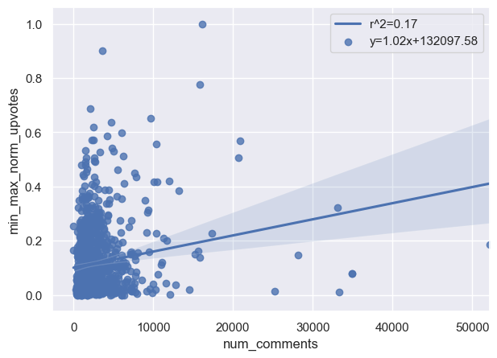

```python
sns.set()

# We calculate various statistics regarding the fit of the line on this data
slope, intercept, r_value, p_value, std_err = stats.linregress(data['num_comments'],data['upvotes'])

# regplot() plots the data and legend() displays the legend on the plot
ax = sns.regplot(x="num_comments", y="min_max_norm_upvotes", data=data, line_kws={'label':"y={0:.2f}x+{1:.2f}".format(slope,intercept), 'label':"r2={0:.2f}".format(r_value)})
ax.legend(labels=['r^2={0:.2f}'.format(r_value), 'y={0:.2f}x+{1:.2f}'.format(slope,intercept)])
plt.show() #Prints the plot to the screen
```

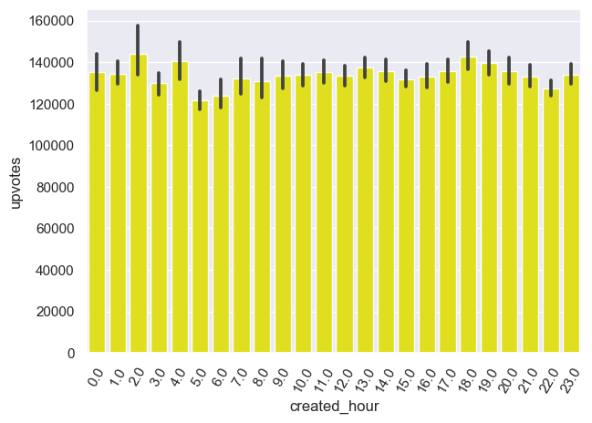

```python
slope, intercept, r_value, p_value, std_err = stats.linregress(data['created_hour'],data['upvotes'])

ax = sns.barplot(x="created_hour", y="upvotes", data=data, color='yellow')
#ax.legend(labels=['r2={0:.2f}'.format(r_value), 'y={0:.2f}x+{1:.2f}'.format(slope,intercept)])
for item in ax.get_xticklabels():
    item.set_rotation(60)
plt.show()
```

It seems that there is no correlation between the hour of post creating and the upvotes a post receives. However, there could a case for emotionally charged posts performing better than other posts. In other words, posts with higher absolute value of title_sentiment could attract more people (because who does not like an emotionally-charged story) and consequently more upvotes. Let's see a plot of title sentiment vs upvotes to get a better feel.

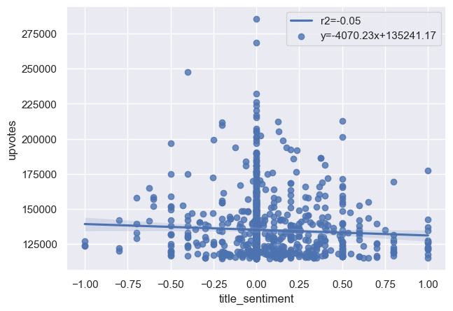

```python
slope, intercept, r_value, p_value, std_err = stats.linregress(data['title_sentiment'],data['upvotes'])

ax = sns.regplot(x="title_sentiment", y="upvotes", data=data)
ax.legend(labels=['r2={0:.2f}'.format(r_value), 'y={0:.2f}x+{1:.2f}'.format(slope,intercept)])
plt.show()
```

Again, we find that there is barely any relation between these two variables as title sentiment seems to be vary by post and various other factors (such as breaking a community rule or posting something offensive) could affect your upvotes a lot. For those people who are not so well-versed with Reddit, you must note that each subReddit has a set of rules that everyone must abide by which are called the ["Community Rules"](https://www.reddit.com/r/modnews/comments/42o2i0/moderators_subreddit_rules_now_available_for_all/). These rules are primarily meant to filter away any offensive content on that SubReddit. Despite this, we must wonder whether a title's length could hold the key to more upvotes. Could a longer title procure more users to your posts and more upvotes or will it have a whiplash effect and deter people away. Let's look at our next plot.

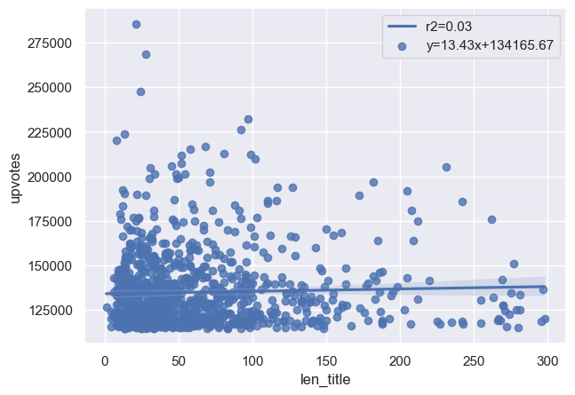

```python
slope, intercept, r_value, p_value, std_err = stats.linregress(data['len_title'],data['upvotes'])

ax = sns.regplot(x="len_title", y="upvotes", data=data)
ax.legend(labels=['r2={0:.2f}'.format(r_value), 'y={0:.2f}x+{1:.2f}'.format(slope,intercept)])
plt.show()
```

Unfortunately there is no relationship here as well as the correlation coefficient's value is extremely low and the general spread of the data seems to be random than linear. With all of these features not seeming to have an effect on the number of upvotes, we must check if subreddit we post in has an effect on the upvotes a post receives. However, we cannot explicitly check that relationship because subreddit is not a numerical variable. However we can see which subreddits had the most amount of popular posts which could potentially tell us on which subreddit we should make our posts on to have the best chance of making it to the top posts.

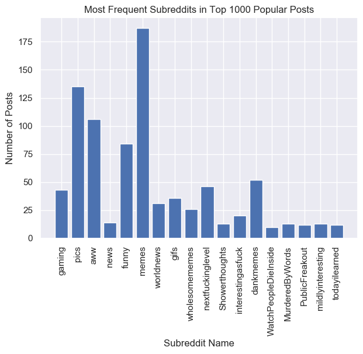

```python
subs = {}
for row in range(len(data.index)):
    subreddit = data.at[row, "subreddit"]
    if subreddit in subs:
        subs[subreddit] = subs[subreddit]+1
    else:
        subs[subreddit] = 1

consistently_top_subs = {}
for sub in subs:
    if subs[sub] >= 10:
        consistently_top_subs[sub] = subs[sub]

# Create bar chart
plt.bar(range(len(consistently_top_subs)), list(consistently_top_subs.values()), align='center')
plt.xticks(range(len(consistently_top_subs)), list(consistently_top_subs.keys()), rotation='vertical')
plt.title("Most Frequent Subreddits in Top 1000 Popular Posts")
plt.ylabel("Number of Posts")
plt.xlabel("Subreddit Name")
plt.show()
```

This plot shows that if we want our post to do well then we must focus on subreddits such as [memes](https://www.reddit.com/r/memes/), [pics](https://www.reddit.com/r/pics/), [aww](https://www.reddit.com/r/aww/) or [funny](https://www.reddit.com/r/funny/) as these subreddits have the highest number of highest ranked posts.

## Machine Learning and Hypothesis Testing

From here, I'd like to put my hypothesis of "subreddit being the most important predictor of upvotes" to the test and see if my features are good enough to predict a post's success at the time of submission?

### Least Squares and Linear Regression

First, we're going try predicting the exact upvotes that a post will achieve based on its initial conditions. This is a regression problem, so let's try fitting our data to a least-squares model and a linear regression model with "upvotes" as our label.

```python
inputRegressionData = []
outputRegressionData = []

#Creating examples with all features and the corresponding label
i = 0
for i in range(0,len(data)):
    subReddit = data.iloc[i]['subreddit']
    SR_oneHotEncoding = subRedditOneHotEncoding["0_" + subReddit].to_list()
    originalContent = data.iloc[i]["is_oc"]
    num_comments = data.iloc[i]["num_comments"]
    nsfw = data.iloc[i]["is_nsfw"]
    lenTitle = data.iloc[i]["len_title"]
    titleQuestion = data.iloc[i]["title_question"]
    titleSentiment = data.iloc[i]["title_sentiment"]
    titleSubjectivity = data.iloc[i]["title_subjectivity"]
    created_hour = data.iloc[i]["created_hour"]
    norm_upvotes = data.iloc[i]["min_max_norm_upvotes"]
    #print(SR_oneHotEncoding)
    inputRegressionData.append(SR_oneHotEncoding + [titleQuestion, lenTitle, titleSentiment, titleSubjectivity, num_comments, originalContent, nsfw, created_hour])
    outputRegressionData.append([norm_upvotes])

# This is simply a dataframe version of the inputRegressionData with column names
inputData_df = pd.DataFrame(inputRegressionData)
outputData_df = pd.DataFrame(outputRegressionData)
inputData_df.columns = lst
outputData_df.columns = ["Normalized_Upvotes"]
```

```python
# We try to fit a OLS Model
X = inputData_df
y = outputData_df
model = sm.OLS(y, X).fit()
predictions = model.predict(X)
model.summary()
```

OLS Regression Results

| Dep. Variable: | Normalized_Upvotes | R-squared: | 0.188 |
| --- | --- | --- | --- |
| Model: | OLS | Adj. R-squared: | 0.107 |
| Method: | Least Squares | F-statistic: | 2.337 |
| Date: | Tue, 19 May 2020 | Prob (F-statistic): | 4.22e-10 |
| Time: | 01:29:05 | Log-Likelihood: | 759.61 |
| No. Observations: | 1000 | AIC: | -1337. |
| Df Residuals: | 909 | BIC: | -890.6 |
| Df Model: | 90 |  |  |
| Covariance Type: | nonrobust |  |  |

|  | coef | std err | t | P>\|t\| | [0.025 | 0.975] |
| --- | --- | --- | --- | --- | --- | --- |
| YouFellForItFool | 0.8619 | 0.121 | 7.126 | 0.000 | 0.625 | 1.099 |
| gaming | 0.0700 | 0.022 | 3.195 | 0.001 | 0.027 | 0.113 |
| pics | 0.1016 | 0.017 | 6.126 | 0.000 | 0.069 | 0.134 |
| aww | 0.0863 | 0.016 | 5.376 | 0.000 | 0.055 | 0.118 |
| news | 0.0685 | 0.038 | 1.820 | 0.069 | -0.005 | 0.142 |
| funny | 0.1050 | 0.017 | 6.066 | 0.000 | 0.071 | 0.139 |
| memes | 0.0939 | 0.013 | 7.476 | 0.000 | 0.069 | 0.119 |
| space | 0.2969 | 0.086 | 3.461 | 0.001 | 0.129 | 0.465 |
| worldnews | -0.0183 | 0.029 | -0.631 | 0.528 | -0.075 | 0.039 |
| gifs | 0.0648 | 0.023 | 2.777 | 0.006 | 0.019 | 0.111 |
| MemeEconomy | 0.4563 | 0.119 | 3.824 | 0.000 | 0.222 | 0.691 |
| PrequelMemes | 0.2082 | 0.050 | 4.198 | 0.000 | 0.111 | 0.306 |
| wholesomememes | 0.0672 | 0.026 | 2.579 | 0.010 | 0.016 | 0.118 |
| AskReddit | 0.0566 | 0.092 | 0.618 | 0.537 | -0.123 | 0.237 |
| nextfuckinglevel | 0.0569 | 0.022 | 2.597 | 0.010 | 0.014 | 0.100 |
| PewdiepieSubmissions | 0.2003 | 0.069 | 2.894 | 0.004 | 0.064 | 0.336 |
| Showerthoughts | 0.1312 | 0.087 | 1.501 | 0.134 | -0.040 | 0.303 |
| interestingasfuck | 0.0648 | 0.031 | 2.118 | 0.034 | 0.005 | 0.125 |
| dankmemes | 0.0463 | 0.019 | 2.414 | 0.016 | 0.009 | 0.084 |
| WatchPeopleDieInside | 0.0695 | 0.039 | 1.776 | 0.076 | -0.007 | 0.146 |
| IsTodayFridayThe13th | 0.2140 | 0.109 | 1.961 | 0.050 | -0.000 | 0.428 |
| Unexpected | 0.1104 | 0.054 | 2.029 | 0.043 | 0.004 | 0.217 |
| comics | 0.2573 | 0.119 | 2.158 | 0.031 | 0.023 | 0.491 |
| DunderMifflin | 0.2146 | 0.119 | 1.796 | 0.073 | -0.020 | 0.449 |
| MurderedByWords | 0.0215 | 0.035 | 0.620 | 0.536 | -0.047 | 0.090 |
| oddlysatisfying | 0.0951 | 0.054 | 1.757 | 0.079 | -0.011 | 0.201 |
| rickandmorty | 0.1503 | 0.086 | 1.754 | 0.080 | -0.018 | 0.318 |
| LifeProTips | 0.0869 | 0.117 | 0.743 | 0.458 | -0.143 | 0.316 |
| Wellthatsucks | 0.0589 | 0.047 | 1.242 | 0.214 | -0.034 | 0.152 |
| PublicFreakout | 0.0078 | 0.037 | 0.210 | 0.833 | -0.065 | 0.081 |

[output cut: 61 more lines]

| Omnibus: | 375.322 | Durbin-Watson: | 0.349 |
| --- | --- | --- | --- |
| Prob(Omnibus): | 0.000 | Jarque-Bera (JB): | 1566.028 |
| Skew: | 1.745 | Prob(JB): | 0.00 |
| Kurtosis: | 8.040 | Cond. No. | 2.89e+05 |

Warnings:  
[1] Standard Errors assume that the covariance matrix of the errors is correctly specified.  
[2] The condition number is large, 2.89e+05. This might indicate that there are  
strong multicollinearity or other numerical problems.

```python
trainInput, testInput, trainOutput, testOutput = train_test_split(inputRegressionData, outputRegressionData, test_size=0.1) #Split data

ratioRegression = Lasso().fit(np.array(trainInput), np.array(trainOutput)) # Works better with sparse data
predictedOutput = ratioRegression.predict(np.array(testInput)) #Test the fitted model against unseen data

modelPerformance = []

testOutput = [i[0] for i in testOutput]
predictedOutput = predictedOutput.tolist()
for i, output in enumerate(zip(testOutput, predictedOutput)):
    target, prediction = output
    modelPerformance.append({"Example" : i, "True " : target , "Predicted Norm_Upvotes" : prediction, "Residual" : target - prediction})

modelPerformance = pd.DataFrame(modelPerformance)
MSE = metrics.mean_squared_error(testOutput, predictedOutput) #How close are the predictions to the actual values?
averageResidual = np.mean(modelPerformance["Residual"]) #Gives an idea if the model is consistently under predicting or overpredicting, indicating a poor fit
modelPerformance #Shows the performance of the fitted linear regression algorithm on our test data
```

|  | Example | True | Predicted Norm_Upvotes | Residual |
| --- | --- | --- | --- | --- |
| 0 | 0 | 0.050020 | 0.130417 | -0.080397 |
| 1 | 1 | 0.077415 | 0.112388 | -0.034973 |
| 2 | 2 | 0.026523 | 0.109729 | -0.083206 |
| 3 | 3 | 0.147894 | 0.115387 | 0.032508 |
| 4 | 4 | 0.296075 | 0.112809 | 0.183267 |
| ... | ... | ... | ... | ... |
| 95 | 95 | 0.055463 | 0.104100 | -0.048637 |
| 96 | 96 | 0.016211 | 0.114395 | -0.098184 |
| 97 | 97 | 0.008211 | 0.104590 | -0.096379 |
| 98 | 98 | 0.087053 | 0.137268 | -0.050215 |
| 99 | 99 | 0.046971 | 0.121621 | -0.074650 |

100 rows × 4 columns

```python
print("Mean Squared Error: " + str(MSE))
print("Average Residual: " + str(averageResidual))
```

```
Mean Squared Error: 0.015134111506104306
Average Residual: -0.004299189771360281
```

Since we have the [residuals](https://stattrek.com/statistics/dictionary.aspx?definition=residual) of our test data, we will plot those residuals to check the strength of our linear regression model. If you do not know how the residual plot can tell us how strong our model is then please check out this [link](http://docs.statwing.com/interpreting-residual-plots-to-improve-your-regression/). The link basically points out that if our residual plot follows these properties then it means that your model is good.

- they’re pretty symmetrically distributed, tending to cluster towards the middle of the plot
- they’re clustered around the lower single digits of the y-axis (e.g., 0.5 or 1.5, not 30 or 150)
- in general there aren’t clear patterns

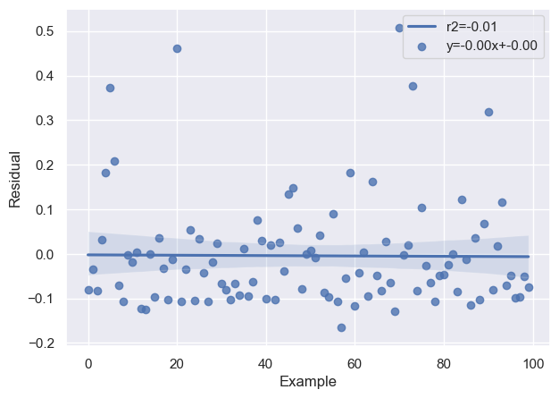

```python
slope, intercept, r_value, p_value, std_err = stats.linregress(modelPerformance['Example'],modelPerformance['Residual'])

ax = sns.regplot(x="Example", y="Residual", data=modelPerformance)
ax.legend(labels=['r2={0:.2f}'.format(r_value), 'y={0:.2f}x+{1:.2f}'.format(slope,intercept)])
plt.show()
```

Plotting the residuals of the test examples shows how healthy our model is and from this plot, we can observe that the line of best fit on the residuals has a slope which is approximately 0 which means that our model fits well on the data when we include the subreddit variable.

### Random Forests

Now we will try and fit this same data by [Random Forests](https://www.newgenapps.com/blog/random-forest-analysis-in-ml-and-when-to-use-it/) because they provide higher accuracy, doesn't allow overfitting easily and it can handle a large dataset with high dimensionality. Although our dataset is relatively small, applying Random Forests could give us higher predictability powers. For those who want to learn more about Random Forests, please check out this [link](https://towardsdatascience.com/understanding-random-forest-58381e0602d2).

```python
# Random Forests

# Create the model with 100 trees
rf = RandomForestRegressor(n_estimators=200)

inputs = np.array(inputData_df)
labels = np.array(outputData_df)

train_features, test_features, train_labels, test_labels = train_test_split(inputs, labels, test_size = 0.25, random_state = 42)

# Fit on training data
rf.fit(train_features, train_labels)

# Use the forest's predict method on the test data
predictions = rf.predict(test_features)

print('score:', rf.score(test_features, test_labels))
```

```
score: -0.06119028951651684
```

The negative score suggests that fitting a random forest model on this data is abysmal, so finally we will try neural networks.

### Neural Networks

We chose Neural Networks because they are more expressive and much powerful linear regressors. If you want to out more about the expressive power of neural networks then please check out [this](https://missinglink.ai/guides/neural-network-concepts/neural-networks-regression-part-1-overkill-opportunity/) .

```python
# Neural Nets
inputRegressionData = []
outputRegressionData = []

#Creating examples with all features and the corresponding label
i = 0
for i in range(0,len(data)):
    subReddit = data.iloc[i]['subreddit']
    SR_oneHotEncoding = subRedditOneHotEncoding["0_" + subReddit].to_list()
    originalContent = data.iloc[i]["is_oc"]
    num_comments = data.iloc[i]["num_comments"]
    nsfw = data.iloc[i]["is_nsfw"]
    lenTitle = data.iloc[i]["len_title"]
    titleQuestion = data.iloc[i]["title_question"]
    titleSentiment = data.iloc[i]["title_sentiment"]
    titleSubjectivity = data.iloc[i]["title_subjectivity"]
    created_hour = data.iloc[i]["created_hour"]
    norm_upvotes = data.iloc[i]["min_max_norm_upvotes"]
    #print(SR_oneHotEncoding)
    inputRegressionData.append(SR_oneHotEncoding + [titleQuestion, lenTitle, titleSentiment, titleSubjectivity, num_comments, originalContent, nsfw, created_hour])
    outputRegressionData.append([norm_upvotes])



trainInput, testInput, trainOutput, testOutput = train_test_split(inputRegressionData, outputRegressionData, test_size=0.1)
testOutput = [i[0] for i in testOutput]

class PredictRedditPost(nn.Module):
    def __init__(self):
        super(PredictRedditPost, self).__init__()
        self.linearClassifier = nn.Sequential(nn.Linear(91, 64), nn.Dropout(0.5), nn.ReLU(),
                                              nn.Linear(64, 16), nn.ReLU(),
                                              nn.Linear(16, 1))
        #Linear fully connected neural network with Dropout regularization to prevent overfitting and ReLU activations for added non-linearity
    def forward(self, featureVector):
        return self.linearClassifier(featureVector)
```

```python
LR = 1e-3 #Learning Rate
WEIGHTDECAY = 0.0005 #L2 Penalty which forces smaller weights and simpler models
EPOCH = 10 #Number of iterations through entire dataset

device = torch.device("cuda:0" if torch.cuda.is_available() else "cpu") #Train on GPU, because training on CPUs is for normies
model = PredictRedditPost()
model.to(device)
optimizer = optim.Adam(model.parameters(), lr=LR, weight_decay=WEIGHTDECAY) #Gradient descent, of the Adam variety. Less fussy than SGD
MSE = nn.MSELoss() #Loss function minimizes mean squared error

TestingMSE = []
TrainingLoss = []
for STEP in range(1, EPOCH + 1):
    epochLoss = 0
    model.train() #Turn on Dropout
    for batchCount, dat in enumerate(zip(trainInput, trainOutput)):
        handCraftedFeatures, ratio = dat

        handCraftedFeatures = torch.tensor(handCraftedFeatures) #Format input to play nice with PyTorch
        ratio = torch.tensor(ratio)

        handCraftedFeatures = handCraftedFeatures.to(device) #Send data to GPU
        ratio = ratio.to(device)

        predictedRatio = model(handCraftedFeatures) #Generate predictions

        optimizer.zero_grad()
        Loss = MSE(predictedRatio, ratio)
        epochLoss = epochLoss + Loss.item()

        Loss.backward() #Backpropagate loss through all layers of NN
        optimizer.step()

    print("Epoch " + str(STEP) +" Loss: " + str(epochLoss / batchCount))
    TrainingLoss.append(epochLoss / batchCount)

    model.eval() #Turn off Dropout
    testInput = torch.tensor(testInput)
    testInput = testInput.to(device)
    predictedRatio = model(testInput) #Forward pass with testing samples

    predictedRatio = [int(i[0]) for i in predictedRatio.tolist()]
    MSError = metrics.mean_squared_error(testOutput, predictedRatio) #Get MSE of testing samples
    print("Epoch " + str(STEP) + " MSE: " + str(MSError) + "\n")
    TestingMSE.append(MSError)
```

```
Epoch 1 Loss: 437.28975537079333
Epoch 1 MSE: 82.49178511519291

Epoch 2 Loss: 118.63363376818369
Epoch 2 MSE: 0.16703582917762916

Epoch 3 Loss: 78.72539820000775
Epoch 3 MSE: 21.123839986675637

Epoch 4 Loss: 16.053210460898896
Epoch 4 MSE: 0.11598404772718673

Epoch 5 Loss: 4.829362022277074
Epoch 5 MSE: 0.021381070059692933

Epoch 6 Loss: 2.0590694658396105
Epoch 6 MSE: 0.021381070059692933

Epoch 7 Loss: 1.0574589895330808
Epoch 7 MSE: 0.021381070059692933

Epoch 8 Loss: 0.9462576749930098
Epoch 8 MSE: 0.021381070059692933

Epoch 9 Loss: 0.4438082917055231
Epoch 9 MSE: 0.021381070059692933

Epoch 10 Loss: 0.18509391231030697
Epoch 10 MSE: 0.021381070059692933
```

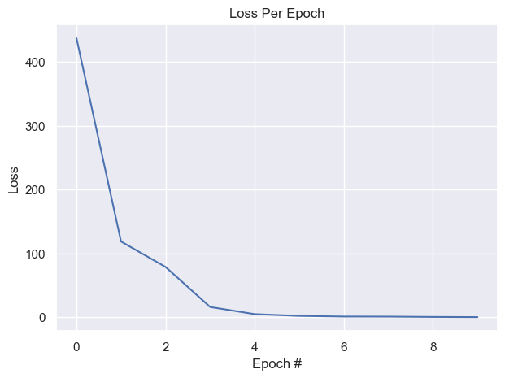

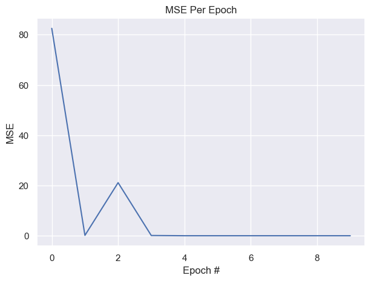

```python
sns.lineplot(x=np.array([x for x in range(EPOCH)]), y=np.array(TrainingLoss)) #Plot training loss per epoch
plt.title("Loss Per Epoch")
plt.xlabel("Epoch #")
plt.ylabel("Loss")
plt.show()
plt.clf()

sns.lineplot(x=np.array([x for x in range(EPOCH)]), y=np.array(TestingMSE)) #Plot MSE on testing set per epoch.
plt.title("MSE Per Epoch")
plt.xlabel("Epoch #")
plt.ylabel("MSE")
plt.show()
plt.clf()
```

```python
# Neural Nets but without Subreddit Features
inputRegressionData = []
outputRegressionData = []

#Creating examples with all features and the corresponding label
i = 0
for i in range(0,len(data)):
    #subReddit = data.iloc[i]['subreddit']
    #SR_oneHotEncoding = subRedditOneHotEncoding["0_" + subReddit].to_list()
    originalContent = data.iloc[i]["is_oc"]
    num_comments = data.iloc[i]["num_comments"]
    nsfw = data.iloc[i]["is_nsfw"]
    lenTitle = data.iloc[i]["len_title"]
    titleQuestion = data.iloc[i]["title_question"]
    titleSentiment = data.iloc[i]["title_sentiment"]
    titleSubjectivity = data.iloc[i]["title_subjectivity"]
    created_hour = data.iloc[i]["created_hour"]
    norm_upvotes = data.iloc[i]["min_max_norm_upvotes"]
    #print(SR_oneHotEncoding)
    inputRegressionData.append([titleQuestion, lenTitle, titleSentiment, titleSubjectivity, num_comments, originalContent, nsfw, created_hour])
    outputRegressionData.append([norm_upvotes])



trainInput, testInput, trainOutput, testOutput = train_test_split(inputRegressionData, outputRegressionData, test_size=0.1)
testOutput = [i[0] for i in testOutput]

class PredictRedditPost(nn.Module):
    def __init__(self):
        super(PredictRedditPost, self).__init__()
        self.linearClassifier = nn.Sequential(nn.Linear(8, 64), nn.Dropout(0.5), nn.ReLU(),
                                              nn.Linear(64, 16), nn.ReLU(),
                                              nn.Linear(16, 1))
        #Linear fully connected neural network with Dropout regularization to prevent overfitting and ReLU activations for added non-linearity
    def forward(self, featureVector):
        return self.linearClassifier(featureVector)
```

```python
LR = 1e-3 #Learning Rate
WEIGHTDECAY = 0.0005 #L2 Penalty which forces smaller weights and simpler models
EPOCH = 10 #Number of iterations through entire dataset

device = torch.device("cuda:0" if torch.cuda.is_available() else "cpu") #Train on GPU, because training on CPUs is for normies
model = PredictRedditPost()
model.to(device)
optimizer = optim.Adam(model.parameters(), lr=LR, weight_decay=WEIGHTDECAY) #Gradient descent, of the Adam variety. Less fussy than SGD
MSE = nn.MSELoss() #Loss function minimizes mean squared error

TestingMSE = []
TrainingLoss = []
for STEP in range(1, EPOCH + 1):
    epochLoss = 0
    model.train() #Turn on Dropout
    for batchCount, dat in enumerate(zip(trainInput, trainOutput)):
        handCraftedFeatures, ratio = dat

        handCraftedFeatures = torch.tensor(handCraftedFeatures) #Format input to play nice with PyTorch
        ratio = torch.tensor(ratio)

        handCraftedFeatures = handCraftedFeatures.to(device) #Send data to GPU
        ratio = ratio.to(device)

        predictedRatio = model(handCraftedFeatures) #Generate predictions

        optimizer.zero_grad()
        Loss = MSE(predictedRatio, ratio)
        epochLoss = epochLoss + Loss.item()

        Loss.backward() #Backpropagate loss through all layers of NN
        optimizer.step()

    print("Epoch " + str(STEP) +" Loss: " + str(epochLoss / batchCount))
    TrainingLoss.append(epochLoss / batchCount)

    model.eval() #Turn off Dropout
    testInput = torch.tensor(testInput)
    testInput = testInput.to(device)
    predictedRatio = model(testInput) #Forward pass with testing samples

    predictedRatio = [int(i[0]) for i in predictedRatio.tolist()]
    MSError = metrics.mean_squared_error(testOutput, predictedRatio) #Get MSE of testing samples
    print("Epoch " + str(STEP) + " MSE: " + str(MSError) + "\n")
    TestingMSE.append(MSError)
```

```
Epoch 1 Loss: 12076.515856473561
Epoch 1 MSE: 480.149265710745

Epoch 2 Loss: 9600.289211253303
Epoch 2 MSE: 6.515763205946073

Epoch 3 Loss: 2340.2415249115106
Epoch 3 MSE: 0.035052849655984805

Epoch 4 Loss: 378.6940065810037
Epoch 4 MSE: 0.035052849655984805

Epoch 5 Loss: 101.69979759880789
Epoch 5 MSE: 0.035052849655984805

Epoch 6 Loss: 66.96205191973313
Epoch 6 MSE: 0.035052849655984805

Epoch 7 Loss: 147.56425311446955
Epoch 7 MSE: 0.035052849655984805

Epoch 8 Loss: 2197.7047757161904
Epoch 8 MSE: 0.035052849655984805

Epoch 9 Loss: 3.5722727904131326
Epoch 9 MSE: 0.035052849655984805

Epoch 10 Loss: 6.289769667487884
Epoch 10 MSE: 0.035052849655984805
```

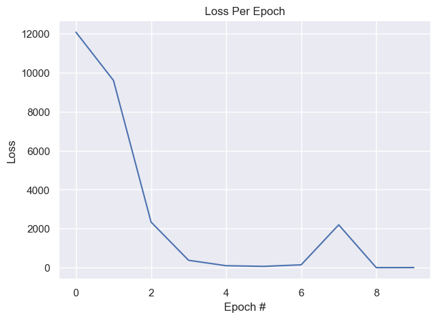

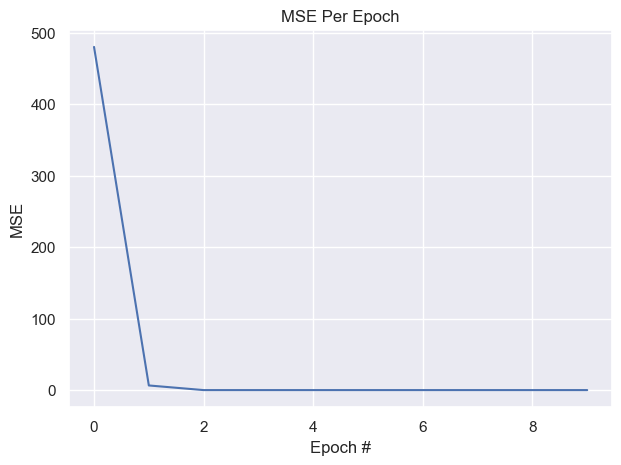

```python
sns.lineplot(x=np.array([x for x in range(EPOCH)]), y=np.array(TrainingLoss)) #Plot training loss per epoch
plt.title("Loss Per Epoch")
plt.xlabel("Epoch #")
plt.ylabel("Loss")
plt.show()
plt.clf()

sns.lineplot(x=np.array([x for x in range(EPOCH)]), y=np.array(TestingMSE)) #Plot MSE on testing set per epoch.
plt.title("MSE Per Epoch")
plt.xlabel("Epoch #")
plt.ylabel("MSE")
plt.show()
plt.clf()
```

The comparison between the two models trained on slightly different datasets is apparent as the loss of the model which was trained on the Dataset with the Subreddit Features performed much better and achieved a loss of 0.18 compared to the model which was trained on a DataSet without the subreddit features which achieved a loss of 6.29 which **35 times** larger than the loss of the previous model. Although, I must admit that I did not have enough training data for a data-hungry regression technique like Neural Net but the difference is still very clear.

As an important note, the limitations of the correlation function mean that we can only use numerical variables for this heatmap. That means we'll be omitting a categorical feature, subreddit, which we already know to be significant.

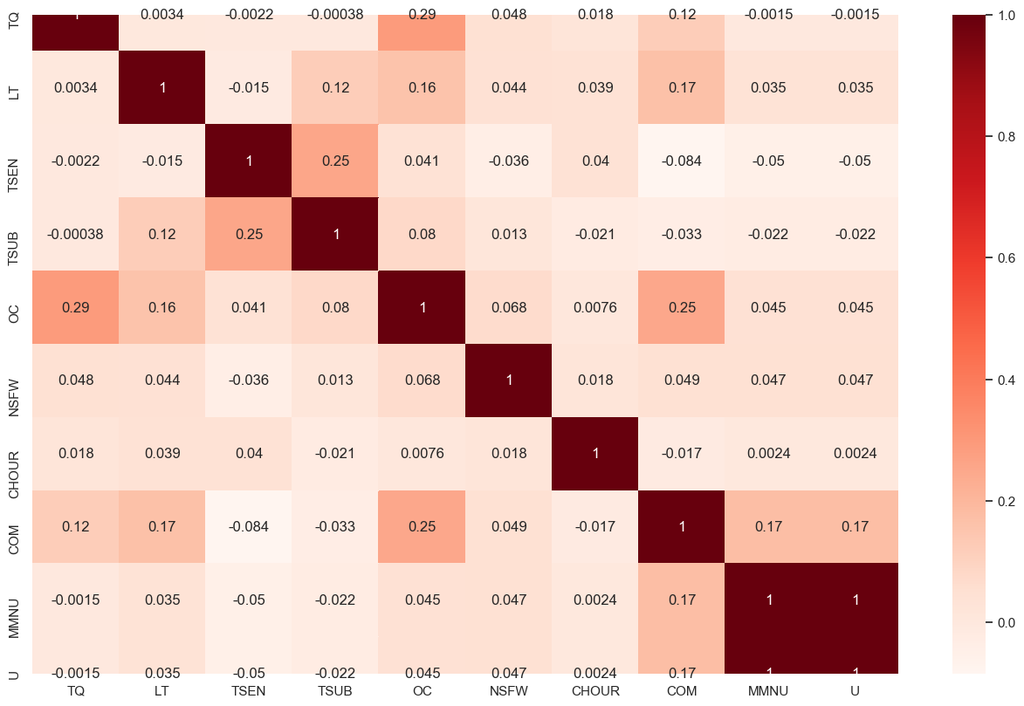

```python
numericalFeatureSelection = []

# Get numerical and boolean features, and abbreviate their labels
for tableRow in data.iterrows():
    lenTitle = tableRow[1]["len_title"]
    titleSentiment = tableRow[1]["title_sentiment"]
    titleSubjectivity = tableRow[1]["title_subjectivity"]
    titleQuestion  =tableRow[1]["title_question"]
    originalContent = tableRow[1]["is_oc"]
    nsfw = tableRow[1]["is_nsfw"]
    hour = tableRow[1]["created_hour"]
    #spoiler = tableRow[1]["is_spoiler"]
    comments = tableRow[1]["num_comments"]
    upvotes = tableRow[1]["upvotes"]
    upvote_norm = tableRow[1]["min_max_norm_upvotes"]

    numericalFeatureSelection.append({"TQ": titleQuestion, "LT" : lenTitle, "TSEN" : titleSentiment, "TSUB" : titleSubjectivity,
                                      "OC" : originalContent, "NSFW" : nsfw, "CHOUR": hour, "COM": comments,
                                      "MMNU": upvote_norm, "U": upvotes})

featureSelection = pd.DataFrame(numericalFeatureSelection)
plt.figure(figsize=(16,10))
pearsonCorrelation = featureSelection.corr() # Pearson's correlation coeff.
sns.heatmap(pearsonCorrelation, annot=True, cmap=plt.cm.Reds) # Using Seaborn to generate a heatmap
plt.show()
```

```python
#Look Up Table for Above Plot
pprint({"TQ": "titleQuestion", "LT" : "lenTitle", "TSEN" : "titleSentiment", "TSUB" : "titleSubjectivity",
        "OC" : "originalContent", "NSFW" : "nsfw", "CHOUR": "hour", "COM": "comments",
        "MMNU": "upvote_norm", "U": "upvotes"})
```

```
{'CHOUR': 'hour',
 'COM': 'comments',
 'LT': 'lenTitle',
 'MMNU': 'upvote_norm',
 'NSFW': 'nsfw',
 'OC': 'originalContent',
 'TQ': 'titleQuestion',
 'TSEN': 'titleSentiment',
 'TSUB': 'titleSubjectivity',
 'U': 'upvotes'}
```

The Correlation Matrix shows us that most if not all of the numerical features do not affect the results of my linear models. The only feature which has been shown to have an effect on the our models has been the "Subreddit" feature. This proves my hypothesis that SubReddit in which you post makes a lot of difference on the amount of upvotes that you get on your post.

## Conclusion

If Reddit interests you, you should definitely explore it because there's so much data left to explore. Reddit hosts over 50 thousand subreddits and over 350 million users, so I've only touched on a very tiny percentage of data that Reddit generates. Even if you're not interested, I hope this tutorial gave you some insight into how a massively popular social news site chooses its top posts. All in all, I hope that it was worth the read and I hope I see your post in that All Subreddit someday.